# Bike Traffic to the Campus

The file `data.txt` contains a list of timestamps indicating the transit of a bike by a counter placed between Niels Bohr Alle and Rødegaardsvej. The recording period goes from 2017-01-01 to 2017-09-30 (hence before the tunnel was constructed) and considers only one direction. There are in all 445883 timestamps.

```python
with open("data.txt") as file:
    timestamps = file.readlines()

print(timestamps[:5])
```

```
['2017-01-01 01:14:32\n', '2017-01-01 01:23:18\n', '2017-01-01 01:25:01\n', '2017-01-01 01:27:57\n', '2017-01-01 01:40:32\n']
```

We handle these data as a data type "time series" implemented in the package `pandas`. This data type has many facilities to handle dates. In particular, in our case it interprets the strings above as dates.

```python
import pandas as pd

# alternative: read data into a data.frame:
# timestamps = pd.read_csv('data.txt', header=None)

tss = pd.Series(1, index=pd.DatetimeIndex(timestamps))
tss
```

```
2017-01-01 01:14:32    1
2017-01-01 01:23:18    1
2017-01-01 01:25:01    1
2017-01-01 01:27:57    1
2017-01-01 01:40:32    1
                      ..
2017-09-30 22:32:13    1
2017-09-30 22:36:57    1
2017-09-30 22:41:12    1
2017-09-30 22:51:06    1
2017-09-30 22:58:35    1
Length: 445883, dtype: int64
```

We resample the time stamps into 1 hour intervals to obtain the main trends for each day.

```python
frequency = tss.resample("1h").sum()
```

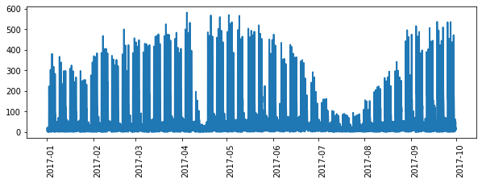

```python
%matplotlib inline
import matplotlib.pyplot as plt

plt.figure(figsize=(10,3))
#xticks = pd.date_range(start=frequency.index.min(),end=frequency.index.max(),freq='D')
plt.xticks(rotation=90,ha="left")
plt.plot(frequency, linewidth=2)
```

Looking at the plot, we can clearly distinguish the patterns for week days and weekends. The pattern for months also seem quite different and zooming in we would discover that also the hour has an influence.

### Your Task

In all we have quite a few data points. We can split them in a set that we will use to train our models and another set, for example the last month, that we will use to test our models.

Two factors seem to be very important: the time of day and the day of the week, when a particular number of bikes occurred. So the input features are the time of the day: $x_1=\{0,1,2,3,...,23\}$ and the day of the week: $x_2=\{0,1,2,\ldots,6\}$ (where $0$ corresponds to Monday and so forth) and the output $y$ is the number of bikes in the corresponding day and hour, which we can assume to be a real number that can be rounded to an integer afterwards.

Consider two linear regression models: \begin{eqnarray*} {\cal H}_1: &&h_1(\vec\theta,\vec x)=\theta_0+\theta_1 x_1 + \theta_2 x_2\\ {\cal H}_2: &&h_2(\vec\theta,\vec x)=\theta_0+\theta_1 x_1 + \theta_2 x_2+\theta_3 x_1x_2 + \theta_4 x_1^2+\theta_5x_2^2 \end{eqnarray*}

- Use the facilities of `pandas` to extract the hour and the day from the dates. Put then the counts, the days and the hours in a `numpy` matrix
- Use `numpy` to fit the two models and determine the two functions $g_1\in {\cal H}_1$ and $g_2\in {\cal H}_2$.
- Plot the predictions of the two models together with the data available. Overimpose the three curves in the same plot with different colors.
- Evaluate the two models by means of the (mean) squared error on the training and on the test set and conclude which of the two models performs better.
- Predict how many bikes will pass on, for example, the 31st of August 2020 from 8 to 9.
- In the analysis so far we did not considered the month as a predictor variable. Repeat the points above including also the month as a regressor. Did the model improve?